# tidymodels_intro

## Working through the tidymodels documentation

Was pretty slow going working through the APM text and trying to update it without having a strong basis in the syntax for tidymodels. So I'm going to take a step back and go through the simple tutorials here for tidymodels.

Link:https://www.tidymodels.org/start/models/

```r
urchins <-
  # Data were assembled for a tutorial
  # at https://www.flutterbys.com.au/stats/tut/tut7.5a.html
  read_csv("https://tidymodels.org/start/models/urchins.csv") %>%
  # Change the names to be a little more verbose
  setNames(c("food_regime", "initial_volume", "width")) %>%
  # Factors are very helpful for modeling, so we convert one column
  mutate(food_regime = factor(food_regime, levels = c("Initial", "Low", "High")))
skimr::skim(urchins)
```

Data summary

| Name | urchins |
| --- | --- |
| Number of rows | 72 |
| Number of columns | 3 |
| _______________________ |  |
| Column type frequency: |  |
| factor | 1 |
| numeric | 2 |
| ________________________ |  |
| Group variables | None |

**Variable type: factor**

| skim_variable | n_missing | complete_rate | ordered | n_unique | top_counts |
| --- | --- | --- | --- | --- | --- |
| food_regime | 0 | 1 | FALSE | 3 | Ini: 24, Low: 24, Hig: 24 |

**Variable type: numeric**

| skim_variable | n_missing | complete_rate | mean | sd | p0 | p25 | p50 | p75 | p100 | hist |
| --- | --- | --- | --- | --- | --- | --- | --- | --- | --- | --- |
| initial_volume | 0 | 1 | 20.88 | 11.30 | 3.50 | 13.00 | 18.00 | 26.00 | 47.50 | ▅▇▃▁▂ |
| width | 0 | 1 | 0.07 | 0.03 | 0.01 | 0.05 | 0.07 | 0.08 | 0.16 | ▁▇▃▂▁ |

## Including Plots

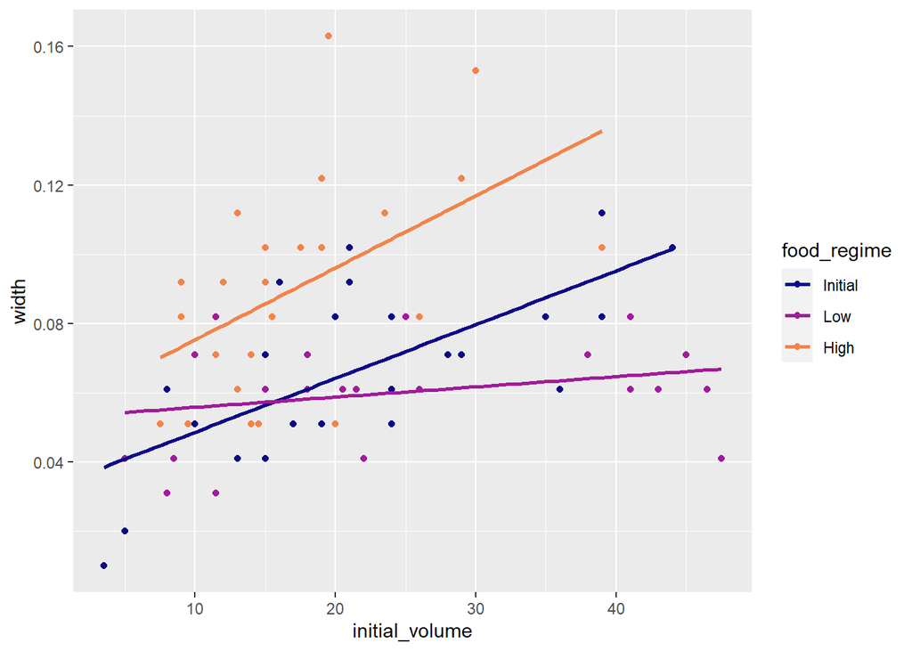

```r
ggplot(urchins, aes(x=initial_volume, y=width, color = food_regime)) +
  geom_point()+
  geom_smooth(method = lm,se=FALSE)+
  scale_color_viridis_d(option = "plasma", end = .7) #nice trick for making colors better
```

Build and fit a simple model. Note that this model contains the normal lm model features in lm_fit$fit. This is an anova model looking at the interaction between the variables as well

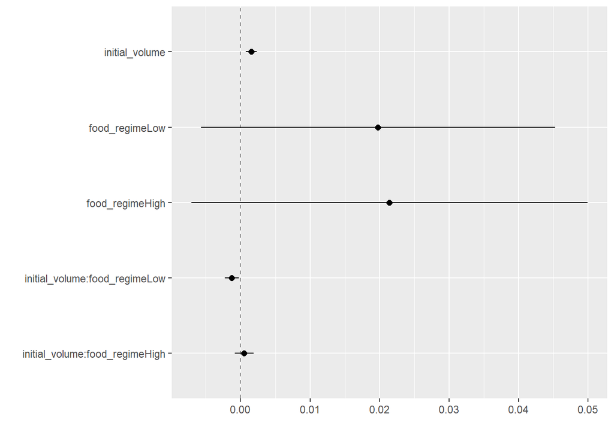

```r
lm_mod <- linear_reg() %>%
  set_engine("lm")

lm_fit <-  lm_mod %>%
  fit(width ~initial_volume * food_regime,data = urchins)

tidy(lm_fit) %>%
  dwplot(dot_args = list(size =2, color = "black"),
         whisker_args = list(color = "black"),
         vline = geom_vline(xintercept = 0, color = "grey50", linetype = 2))
```

# Using some of the extra parsnip features

One major benefit is all the tidy models can calculate the variability using a common syntax, instead of having to rewrite every time.

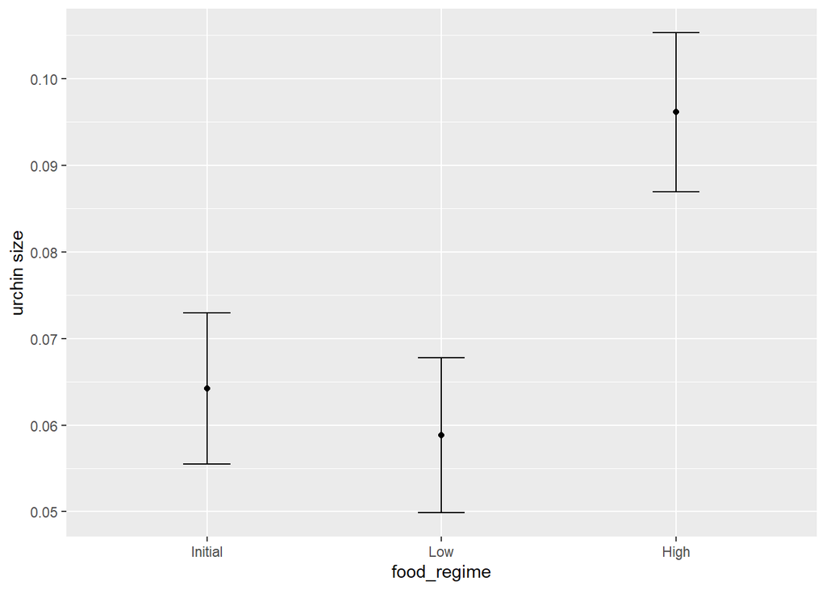

```r
new_points <- expand.grid(initial_volume = 20, food_regime=c("Initial", "Low", "High"))

mean_pred <-  predict(lm_fit,new_data = new_points)
conf_int_pred <- predict(lm_fit, new_data = new_points, type="conf_int")

#bind data together, this is the power of tidy
plot_data <- new_points %>%
  bind_cols(mean_pred) %>%
  bind_cols(conf_int_pred)

ggplot(plot_data, aes(x= food_regime)) +
  geom_point(aes(y=.pred)) +
  geom_errorbar(aes(ymin = .pred_lower, ymax = .pred_upper), width = .2) +
  labs(y="urchin size")
```

Changing the model engine: using a bayesian model (our old friend stan). This does the same thing as abve using a bayesian approach, but it's possible that it's like, really slow. Especially on my laptop.

```r
# set the prior distribution
prior_dist <- rstanarm::student_t(df = 1)

set.seed(123)

# make the parsnip model
bayes_mod <-
  linear_reg() %>%
  set_engine("stan",
             prior_intercept = prior_dist,
             prior = prior_dist)

# train the model
bayes_fit <-
  bayes_mod %>%
  fit(width ~ initial_volume * food_regime, data = urchins)

print(bayes_fit, digits = 5)
```

```
## parsnip model object
##
## Fit time:  37.8s
## stan_glm
##  family:       gaussian [identity]
##  formula:      width ~ initial_volume * food_regime
##  observations: 72
##  predictors:   6
## ------
##                                Median   MAD_SD
## (Intercept)                     0.03312  0.00954
## initial_volume                  0.00155  0.00041
## food_regimeLow                  0.01999  0.01279
## food_regimeHigh                 0.02158  0.01433
## initial_volume:food_regimeLow  -0.00126  0.00052
## initial_volume:food_regimeHigh  0.00053  0.00071
##
## Auxiliary parameter(s):
##       Median  MAD_SD
## sigma 0.02131 0.00193
##
## ------
## * For help interpreting the printed output see ?print.stanreg
## * For info on the priors used see ?prior_summary.stanreg
```

```r
bayes_plot_data <-
  new_points %>%
  bind_cols(predict(bayes_fit, new_data = new_points)) %>%
  bind_cols(predict(bayes_fit, new_data = new_points, type = "conf_int"))
```

```
## Instead of posterior_linpred(..., transform=TRUE) please call posterior_epred(), which provides equivalent functionality.
```

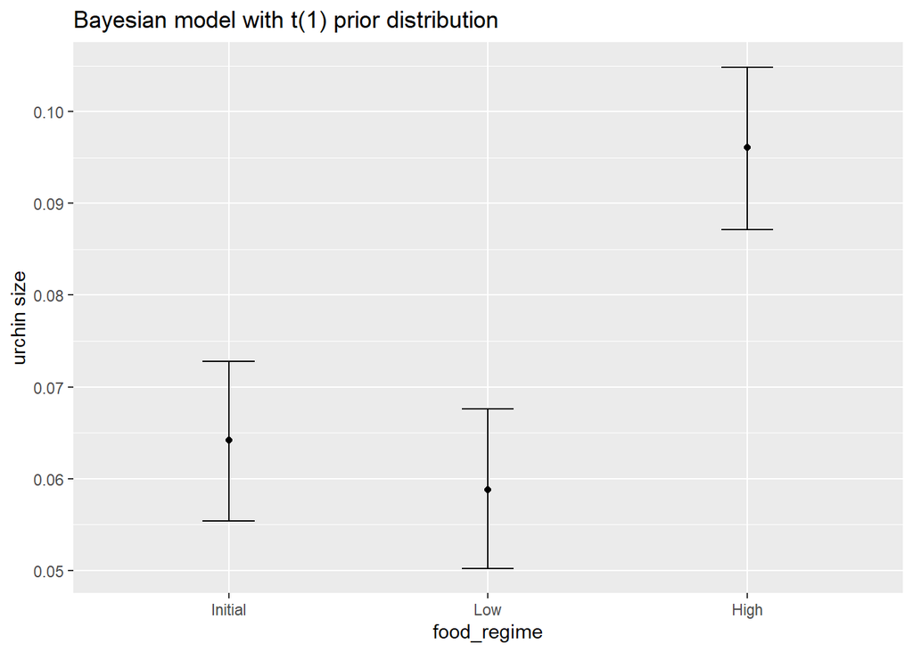

```r
ggplot(bayes_plot_data, aes(x = food_regime)) +
  geom_point(aes(y = .pred)) +
  geom_errorbar(aes(ymin = .pred_lower, ymax = .pred_upper), width = .2) +
  labs(y = "urchin size") +
  ggtitle("Bayesian model with t(1) prior distribution")
```

The useful idea around the whole tidymodels framework is to standardizethe interfaces with models. That means you can change the whole model (as using the stan approach here) but keep everything else the same. Super useful for iterating model development.

## Using recipes to pre-process data

```r
library(nycflights13)
set.seed(123)
data(flights)
flight_data <- flights %>%
  mutate(
    # Convert the arrival delay to a factor
    arr_delay = ifelse(arr_delay >= 30, "late", "on_time"),
    arr_delay = factor(arr_delay),
    # We will use the date (not date-time) in the recipe below
    date = as.Date(time_hour)
  ) %>%
  # Include the weather data
  inner_join(weather, by = c("origin", "time_hour")) %>%
  # Only retain the specific columns we will use
  select(dep_time, flight, origin, dest, air_time, distance,
         carrier, date, arr_delay, time_hour) %>%
  # Exclude missing data
  na.omit() %>%
  # For creating models, it is better to have qualitative columns
  # encoded as factors (instead of character strings)
  mutate(across(where(is.character), as.factor)) #I updated this to use the new standard with across instead of

skimr::skim(flight_data)
```

Data summary

| Name | flight_data |
| --- | --- |
| Number of rows | 325819 |
| Number of columns | 10 |
| _______________________ |  |
| Column type frequency: |  |
| Date | 1 |
| factor | 4 |
| numeric | 4 |
| POSIXct | 1 |
| ________________________ |  |
| Group variables | None |

**Variable type: Date**

| skim_variable | n_missing | complete_rate | min | max | median | n_unique |
| --- | --- | --- | --- | --- | --- | --- |
| date | 0 | 1 | 2013-01-01 | 2013-12-30 | 2013-07-03 | 364 |

**Variable type: factor**

| skim_variable | n_missing | complete_rate | ordered | n_unique | top_counts |
| --- | --- | --- | --- | --- | --- |
| origin | 0 | 1 | FALSE | 3 | EWR: 116504, JFK: 108539, LGA: 100776 |
| dest | 0 | 1 | FALSE | 104 | ATL: 16771, ORD: 16507, LAX: 15942, BOS: 14948 |
| carrier | 0 | 1 | FALSE | 16 | UA: 57489, B6: 53715, EV: 50868, DL: 47465 |
| arr_delay | 0 | 1 | FALSE | 2 | on_: 273279, lat: 52540 |

**Variable type: numeric**

| skim_variable | n_missing | complete_rate | mean | sd | p0 | p25 | p50 | p75 | p100 | hist |
| --- | --- | --- | --- | --- | --- | --- | --- | --- | --- | --- |
| dep_time | 0 | 1 | 1348.15 | 487.92 | 1 | 907 | 1400 | 1743 | 2400 | ▁▇▆▇▃ |
| flight | 0 | 1 | 1943.54 | 1621.73 | 1 | 544 | 1471 | 3416 | 8500 | ▇▃▃▁▁ |
| air_time | 0 | 1 | 150.63 | 93.66 | 20 | 82 | 129 | 191 | 695 | ▇▂▂▁▁ |
| distance | 0 | 1 | 1048.18 | 735.86 | 80 | 509 | 888 | 1389 | 4983 | ▇▃▂▁▁ |

**Variable type: POSIXct**

| skim_variable | n_missing | complete_rate | min | max | median | n_unique |
| --- | --- | --- | --- | --- | --- | --- |
| time_hour | 0 | 1 | 2013-01-01 05:00:00 | 2013-12-30 18:00:00 | 2013-07-03 15:00:00 | 6885 |

```r
set.seed(555)
data_split <-  initial_split(flight_data, prop = .75)

train_data <- training(data_split)
test_data <- testing(data_split)

flights_rec <-  recipe(arr_delay ~., data = train_data) %>%
  update_role(flight, time_hour, new_role = "ID") #this is used to keep these variables in the data but not use them for the model.

summary(flights_rec)
```

```
## # A tibble: 10 x 4
##    variable  type    role      source
##    <chr>     <chr>   <chr>     <chr>
##  1 dep_time  numeric predictor original
##  2 flight    numeric ID        original
##  3 origin    nominal predictor original
##  4 dest      nominal predictor original
##  5 air_time  numeric predictor original
##  6 distance  numeric predictor original
##  7 carrier   nominal predictor original
##  8 date      date    predictor original
##  9 time_hour date    ID        original
## 10 arr_delay nominal outcome   original
```

```r
#feature engineering as part of recipe
flights_rec <- recipe(arr_delay ~., data = train_data) %>%
  update_role(flight, time_hour, new_role = "ID") %>%
  step_date(date,features = c("dow","month")) %>%
  step_holiday(date, holidays = timeDate::listHolidays("US")) %>%
  step_rm(date) %>%
  step_dummy(all_nominal(), -all_outcomes()) %>%
  step_zv(all_predictors()) #removes any features with only one value

test <- prep(flights_rec)

summary(test)
```

```
## # A tibble: 159 x 4
##    variable                     type    role      source
##    <chr>                        <chr>   <chr>     <chr>
##  1 dep_time                     numeric predictor original
##  2 flight                       numeric ID        original
##  3 air_time                     numeric predictor original
##  4 distance                     numeric predictor original
##  5 time_hour                    date    ID        original
##  6 arr_delay                    nominal outcome   original
##  7 date_USChristmasDay          numeric predictor derived
##  8 date_USColumbusDay           numeric predictor derived
##  9 date_USCPulaskisBirthday     numeric predictor derived
## 10 date_USDecorationMemorialDay numeric predictor derived
## # ... with 149 more rows
```

Step of making a model happen in tidymodels 1. Process the recipe using the training set 2. Apply the recipe to the training set 3. Apply the recipe to the test set

```r
lr_mod <- logistic_reg() %>%
  set_engine("glm")

flights_workflow <- workflow() %>%
  add_model(lr_mod) %>%
  add_recipe(flights_rec)

flights_workflow
```

```
## == Workflow ====================================================================
## Preprocessor: Recipe
## Model: logistic_reg()
##
## -- Preprocessor ----------------------------------------------------------------
## 5 Recipe Steps
##
## * step_date()
## * step_holiday()
## * step_rm()
## * step_dummy()
## * step_zv()
##
## -- Model -----------------------------------------------------------------------
## Logistic Regression Model Specification (classification)
##
## Computational engine: glm
```

```r
flights_fit <- flights_workflow %>%
  fit(data = train_data)

flights_fit %>% pull_workflow_fit() %>% tidy()
```

```
## # A tibble: 157 x 5
##    term                         estimate std.error statistic  p.value
##    <chr>                           <dbl>     <dbl>     <dbl>    <dbl>
##  1 (Intercept)                   3.91    2.73           1.43 1.51e- 1
##  2 dep_time                     -0.00167 0.0000141   -118.   0.
##  3 air_time                     -0.0439  0.000561     -78.4  0.
##  4 distance                      0.00686 0.00150        4.57 4.84e- 6
##  5 date_USChristmasDay           1.12    0.173          6.49 8.45e-11
##  6 date_USColumbusDay            0.474   0.159          2.99 2.81e- 3
##  7 date_USCPulaskisBirthday      0.864   0.139          6.21 5.47e-10
##  8 date_USDecorationMemorialDay  0.279   0.110          2.53 1.15e- 2
##  9 date_USElectionDay            0.696   0.169          4.12 3.82e- 5
## 10 date_USGoodFriday             1.28    0.166          7.71 1.27e-14
## # ... with 147 more rows
```

Using the trained model for prediction is one more step

```r
flights_pred <- predict(flights_fit, test_data, type = "prob") %>%
  bind_cols(test_data %>% select(arr_delay, time_hour, flight))

flights_pred
```

```
## # A tibble: 81,454 x 5
##    .pred_late .pred_on_time arr_delay time_hour           flight
##         <dbl>         <dbl> <fct>     <dttm>               <int>
##  1     0.0565         0.944 on_time   2013-01-01 05:00:00   1714
##  2     0.0264         0.974 on_time   2013-01-01 06:00:00     79
##  3     0.0481         0.952 on_time   2013-01-01 06:00:00    301
##  4     0.0325         0.967 on_time   2013-01-01 06:00:00     49
##  5     0.0711         0.929 on_time   2013-01-01 06:00:00   1187
##  6     0.0583         0.942 on_time   2013-01-01 06:00:00   4401
##  7     0.0171         0.983 on_time   2013-01-01 06:00:00   1895
##  8     0.0458         0.954 on_time   2013-01-01 06:00:00    135
##  9     0.0221         0.978 on_time   2013-01-01 06:00:00   4646
## 10     0.0502         0.950 on_time   2013-01-01 06:00:00   4144
## # ... with 81,444 more rows
```

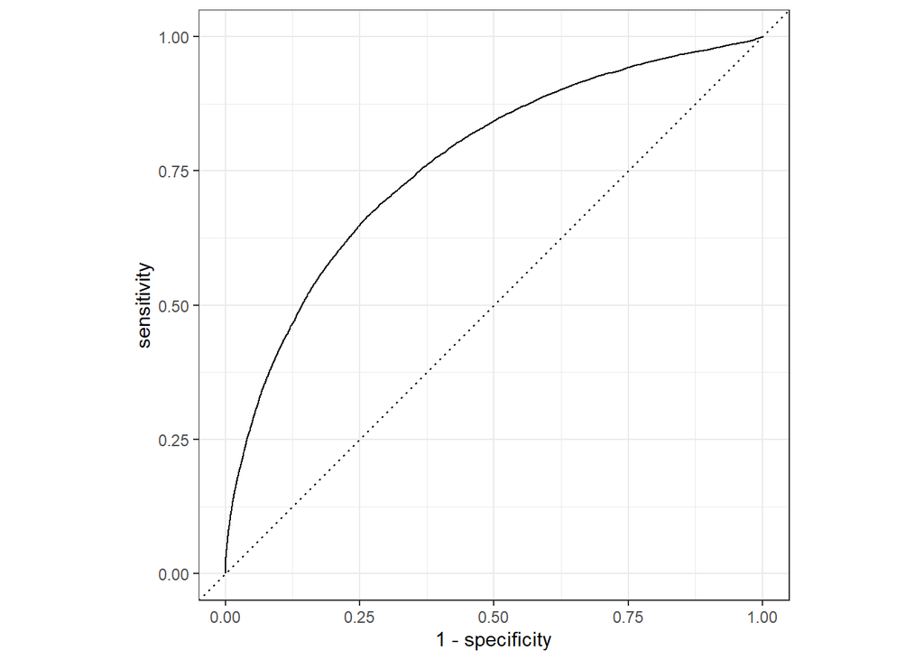

```r
#evaluate using AUC

flights_pred %>% roc_curve(truth = arr_delay, .pred_late) %>%
  autoplot()
```

```r
flights_pred %>% roc_auc(truth = arr_delay, .pred_late)
```

```
## # A tibble: 1 x 3
##   .metric .estimator .estimate
##   <chr>   <chr>          <dbl>
## 1 roc_auc binary         0.765
```

# Evaluate your model with resampling

```r
library(modeldata)

data("cells")

glimpse(cells)
```

```
## Rows: 2,019
## Columns: 58
## $ case                         <fct> Test, Train, Train, Train, Test, Test,...
## $ class                        <fct> PS, PS, WS, PS, PS, WS, WS, PS, WS, WS...
## $ angle_ch_1                   <dbl> 143.247705, 133.752037, 106.646387, 69...
## $ area_ch_1                    <int> 185, 819, 431, 298, 285, 172, 177, 251...
## $ avg_inten_ch_1               <dbl> 15.71186, 31.92327, 28.03883, 19.45614...
## $ avg_inten_ch_2               <dbl> 4.954802, 206.878517, 116.315534, 102....
## $ avg_inten_ch_3               <dbl> 9.548023, 69.916880, 63.941748, 28.217...
## $ avg_inten_ch_4               <dbl> 2.214689, 164.153453, 106.696602, 31.0...
## $ convex_hull_area_ratio_ch_1  <dbl> 1.124509, 1.263158, 1.053310, 1.202625...
## $ convex_hull_perim_ratio_ch_1 <dbl> 0.9196827, 0.7970801, 0.9354750, 0.865...
## $ diff_inten_density_ch_1      <dbl> 29.51923, 31.87500, 32.48771, 26.73228...
## $ diff_inten_density_ch_3      <dbl> 13.77564, 43.12228, 35.98577, 22.91732...
## $ diff_inten_density_ch_4      <dbl> 6.826923, 79.308424, 51.357050, 26.393...
```

[output cut: 45 more lines]

```r
cells %>% count(class) %>%
  mutate(prop = n/sum(n))
```

```
## # A tibble: 2 x 3
##   class     n  prop
##   <fct> <int> <dbl>
## 1 PS     1300 0.644
## 2 WS      719 0.356
```

```r
set.seed(123)
cell_split <- initial_split(cells %>% select(-case), strata = class)

cell_train <- training(cell_split)
cell_test <- testing(cell_split)
```

fitting a random forest model. There is no recipe used for this model, since random forest handles variable weirdness pretty well and you don't need to do a ton of preprocessing. Note that I expect this to be pretty slow on a laptop... aaand it's not. Like 5 seconds.

```r
rf_mod <- rand_forest(trees = 1000) %>%
  set_engine("ranger") %>%
  set_mode("classification")

set.seed(234)
rf_fit <-  rf_mod %>%
  fit(class ~.,data = cell_train)
rf_fit
```

```
## parsnip model object
##
## Fit time:  4.8s
## Ranger result
##
## Call:
##  ranger::ranger(x = maybe_data_frame(x), y = y, num.trees = ~1000,      num.threads = 1, verbose = FALSE, seed = sample.int(10^5,          1), probability = TRUE)
##
## Type:                             Probability estimation
## Number of trees:                  1000
## Sample size:                      1515
## Number of independent variables:  56
## Mtry:                             7
## Target node size:                 10
## Variable importance mode:         none
## Splitrule:                        gini
## OOB prediction error (Brier s.):  0.1220191
```

Estimating performance: Going to use AUC and classification accuracy **Note that in the tidyverse the folds are referred to as having 'analysis' and 'assessment' subsets)**

```r
set.seed(345)
folds <-  vfold_cv(cell_train, v=10)

rf_wf <-  workflow()%>%
  add_model(rf_mod) %>%
  add_formula(class ~.)

set.seed(456)
rf_fit_rs <- rf_wf %>%
  fit_resamples(folds)
collect_metrics(rf_fit_rs)
```

```
## # A tibble: 2 x 6
##   .metric  .estimator  mean     n std_err .config
##   <chr>    <chr>      <dbl> <int>   <dbl> <chr>
## 1 accuracy binary     0.830    10 0.0110  Preprocessor1_Model1
## 2 roc_auc  binary     0.903    10 0.00815 Preprocessor1_Model1
```

```r
rf_testing_pred <-
  predict(rf_fit, cell_test) %>%
  bind_cols(predict(rf_fit, cell_test, type = "prob")) %>%
  bind_cols(cell_test %>% select(class))

rf_testing_pred %>%                   # test set predictions
  roc_auc(truth = class, .pred_PS)
```

```
## # A tibble: 1 x 3
##   .metric .estimator .estimate
##   <chr>   <chr>          <dbl>
## 1 roc_auc binary         0.909
```

```r
rf_testing_pred %>%                   # test set predictions
  accuracy(truth = class, .pred_class)
```

```
## # A tibble: 1 x 3
##   .metric  .estimator .estimate
##   <chr>    <chr>          <dbl>
## 1 accuracy binary         0.841
```

## Model tuning

Lets make a decision tree and tune the parameters to get it working well

```r
library(vip)
#note that thi is using the same cell data from before, so if starting from here you'll need to reload it

tune_spec <-
  decision_tree(
  cost_complexity = tune(),
  tree_depth = tune()
  ) %>%
  set_engine("rpart") %>%
  set_mode("classification")

tree_grid <-  grid_regular(cost_complexity(),
                           tree_depth(),
                           levels=5)

set.seed(345)
tree_wf <- workflow() %>%
  add_model(tune_spec) %>%
  add_formula(class ~.)

tree_res <- tree_wf %>%
  tune_grid(
    resamples = folds,
    grid = tree_grid
  )
```

Plotting results

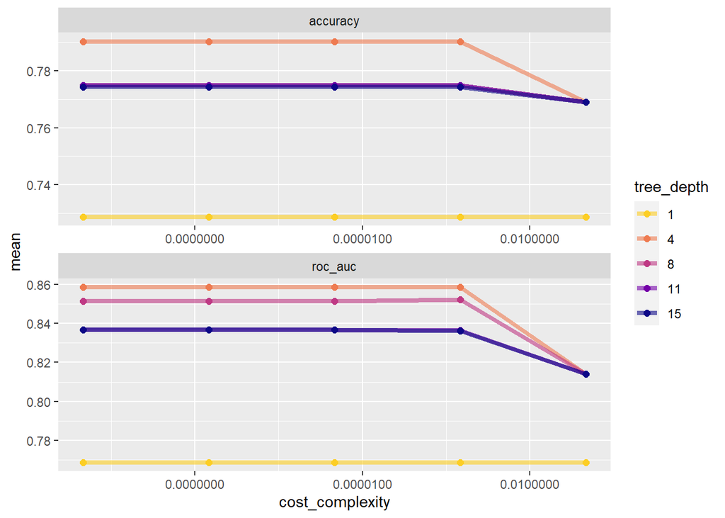

```r
tree_res %>%
  collect_metrics() %>%
  mutate(tree_depth = factor(tree_depth)) %>%
  ggplot(aes(cost_complexity, mean, color = tree_depth)) +
  geom_line(size = 1.5, alpha = 0.6) +
  geom_point(size = 2) +
  facet_wrap(~ .metric, scales = "free", nrow = 2) +
  scale_x_log10(labels = scales::label_number()) +
  scale_color_viridis_d(option = "plasma", begin = .9, end = 0)
```

```r
tree_res %>%
  show_best("roc_auc")
```

```
## # A tibble: 5 x 8
##   cost_complexity tree_depth .metric .estimator  mean     n std_err .config
##             <dbl>      <int> <chr>   <chr>      <dbl> <int>   <dbl> <chr>
## 1    0.0000000001          4 roc_auc binary     0.859    10  0.0113 Preprocesso~
## 2    0.0000000178          4 roc_auc binary     0.859    10  0.0113 Preprocesso~
## 3    0.00000316            4 roc_auc binary     0.859    10  0.0113 Preprocesso~
## 4    0.000562              4 roc_auc binary     0.859    10  0.0113 Preprocesso~
## 5    0.000562              8 roc_auc binary     0.852    10  0.0121 Preprocesso~
```

```r
best_tree <-tree_res %>%
  select_best("roc_auc")

best_tree
```

```
## # A tibble: 1 x 3
##   cost_complexity tree_depth .config
##             <dbl>      <int> <chr>
## 1    0.0000000001          4 Preprocessor1_Model06
```

```r
final_wf <- tree_wf %>%
  finalize_workflow(best_tree)
```

Exploring the results

```r
final_tree <- final_wf %>%
  fit(data = cell_train)

final_tree
```

```
## == Workflow [trained] ==========================================================
## Preprocessor: Formula
## Model: decision_tree()
##
## -- Preprocessor ----------------------------------------------------------------
## class ~ .
##
## -- Model -----------------------------------------------------------------------
## n= 1515
##
## node), split, n, loss, yval, (yprob)
##       * denotes terminal node
##
##  1) root 1515 540 PS (0.64356436 0.35643564)
##    2) total_inten_ch_2< 47256.5 731  63 PS (0.91381669 0.08618331)
##      4) total_inten_ch_2< 37166 585  19 PS (0.96752137 0.03247863) *
##      5) total_inten_ch_2>=37166 146  44 PS (0.69863014 0.30136986)
##       10) avg_inten_ch_1< 99.15056 98  14 PS (0.85714286 0.14285714) *
##       11) avg_inten_ch_1>=99.15056 48  18 WS (0.37500000 0.62500000)
##         22) fiber_align_2_ch_3>=1.47949 20   8 PS (0.60000000 0.40000000) *
##         23) fiber_align_2_ch_3< 1.47949 28   6 WS (0.21428571 0.78571429) *
##    3) total_inten_ch_2>=47256.5 784 307 WS (0.39158163 0.60841837)
##      6) fiber_width_ch_1< 11.19756 329 137 PS (0.58358663 0.41641337)
##       12) avg_inten_ch_1< 194.4183 254  82 PS (0.67716535 0.32283465) *
##       13) avg_inten_ch_1>=194.4183 75  20 WS (0.26666667 0.73333333)
##         26) total_inten_ch_3>=62458.5 23   9 PS (0.60869565 0.39130435) *
##         27) total_inten_ch_3< 62458.5 52   6 WS (0.11538462 0.88461538) *
##      7) fiber_width_ch_1>=11.19756 455 115 WS (0.25274725 0.74725275)
##       14) shape_p_2_a_ch_1>=1.225676 300  97 WS (0.32333333 0.67666667)
##         28) avg_inten_ch_2>=362.0108 55  23 PS (0.58181818 0.41818182) *
##         29) avg_inten_ch_2< 362.0108 245  65 WS (0.26530612 0.73469388) *
##       15) shape_p_2_a_ch_1< 1.225676 155  18 WS (0.11612903 0.88387097) *
```

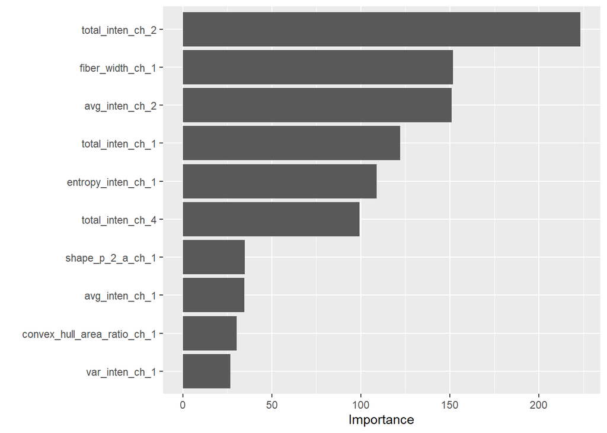

```r
#looking at variable importance

final_tree %>%
  pull_workflow_fit()%>%
  vip()
```

```r
final_fit <-
  final_wf %>%
  last_fit(cell_split) #this last_fit function will fit the split data training set and then evaluate on the split data test set.

final_fit %>%
  collect_metrics()
```

```
## # A tibble: 2 x 4
##   .metric  .estimator .estimate .config
##   <chr>    <chr>          <dbl> <chr>
## 1 accuracy binary         0.802 Preprocessor1_Model1
## 2 roc_auc  binary         0.860 Preprocessor1_Model1
```

[output not shown]

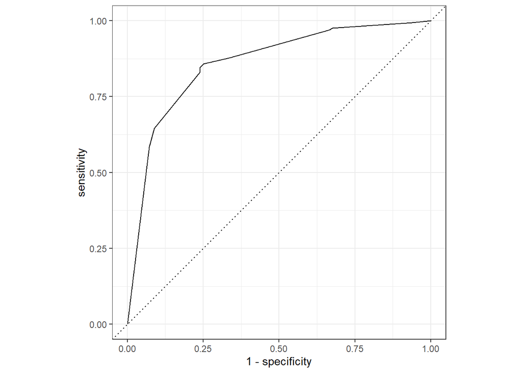

```r
final_fit %>%
  collect_predictions() %>%
  roc_curve(class, .pred_PS) %>%
  autoplot()
```